# Running user-defined functions in R on Earth observation data in cloud back-ends

*Pramit Ghosh*, Florian Lahn, Soeren Gebbert, Matthias Mohr and Edzer Pebesma

Institute for Geoinformatics, WWU Muenster, Germany

08.12.2018 at Geomundus, '18 in Lisbon, Portugal

### Have you ever used satellite images?

*Let's have a show of hands!*

[figure not shown]

### So, what's the "traditional" workflow for satellite images?

Usually, it involves the following

- Selecting appropriate sensors
- Downloading it locally
- Processing and analysis

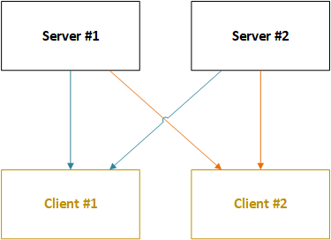

### What is the problem with this?

Apparently, nothing! But, imagine processing a 30 years long time-series of LANDSAT data, say to calculate NDVI.

New problems

- Bandwidth
- Computing power

Challenges

- Rapid launch of new satellites
- Increase in resolution

EO data is big data and alternate workflows are required.

### How to deal with this problem?

Upload the code and let the processing take place in the cloud instead. Advantages:

- Overcomes bandwith limitations
- More computing power

Will allow the back-ends to be used by client nodes using different programing languages, mediated by a common API

### openEO: Open Earth Observation

The openEO project does exactly that.

[figure not shown]

Develops an API to allow clients using Javascript, R or Python to send processing requests to cloud back-ends

### User-defined Functions (UDFs) in openEO

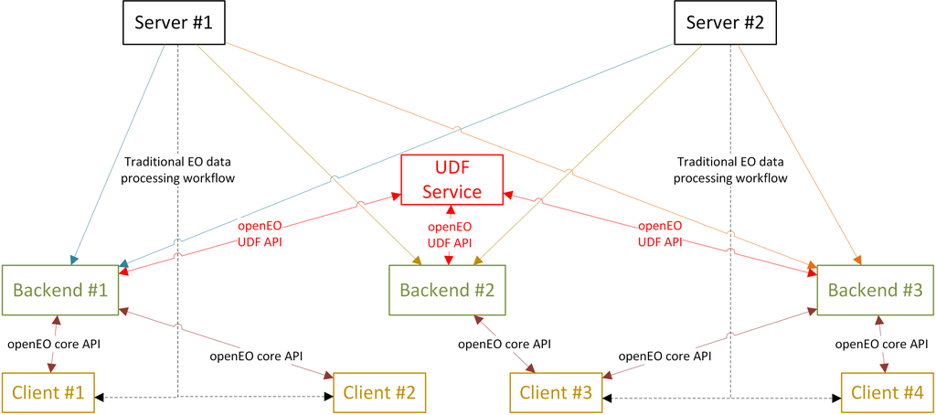

UDFs allow to users operating the client to run their own custom code on EO data too instead of only those natively available in the cloud back-ends.

### UDFs in R

[figure not shown]

R package `openEO.R.UDF` (Ghosh and Lahn, 2018) implements three strategies to develop services for running UDFs on EO data using the `stars` package (Pebesma, 2018)

### Strategy 1: File-based service

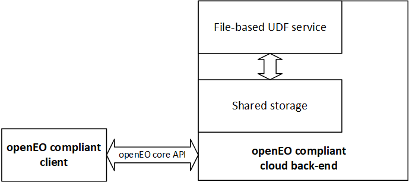

- Data (GeoTIFF files) and a look-up table (CSV file) written to disk
- Converts data to `stars` object, executes user's R script and write resultant object to disk
- Practically, the UDF service is a part of the back-end

### Strategy 2: RESTful web service using JSON arrays

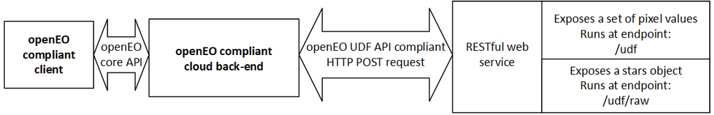

- Data sent to a web service by writing pixel values in JSON arrays
- Data sent and results received in the form of openEO UDF API compliant HTTP POST requests and responses respectively
- RESTful server has two end-points
  - `/udf` exposes only a list of values to the UDF
  - `/udf/raw` exposes the entire `stars` object to the UDF

### Strategy 3: RESTful web service using base64 encoded string

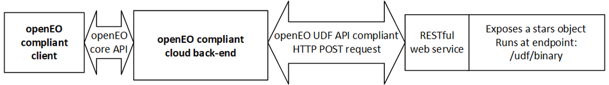

- Similar to Strategy 2 with an endpoint `/udf/binary`
- Except data represented as a base64 encoded string of a compressed ZIP file containing GeoTIFF files
- This string is embedded along with other metadata as a JSON in the POST body

### Containerization using Docker

- The R package has been containerized using Docker (Merkel, 2014) for reproducibility and testing the web services
- It is available publicly on Docker Hub at the following URL: https://hub.docker.com/r/pramitghosh/openeo.r.udf/

[figure not shown]

### Future Directions

openEO aims to pursue UDFs for EO data processing in the cloud. Some challenges ahead:

- In order for the UDF service(s) to handle big data, it needs to be scalable. For this, the data from the backend could be sliced into smaller chunks. The slicing strategy would be based on which dimension of the EO data cube the UDF is being applied on. These smaller chunks could be sent to multiple UDF services for parallel processing in the cloud and then stichting the individual results back.
- Further development of the openEO UDF API for R and Python

### References

- Ghosh, P., and Lahn, F. (2018), openEO.R.UDF: User-defined functions (UDF) in R on Earth observation data in cloud back-ends. R package version 0.0.3. https://github.com/pramitghosh/openEO.R.UDF
- Merkel, D. (2014), Docker: lightweight linux containers for consistent development and deployment. Linux Journal, 2014 (239).
- Pebesma, E. (2018), stars: Scalable, Spatiotemporal Tidy Arrays. R package version 0.2-0. https://CRAN.R-project.org/package=stars

### Acknowledgements

This project has received funding from the European Union's Horizon 2020 research and innovation programme under grant agreement No. 776242. This publication only reflects the author's views; the European Commission is not responsible for any use that may be made of the information it contains.

[figure not shown]

### Thank you!

Questions?

- now
- by email: pramitghosh@uni-muenster.de

Further information

- openEO site: http://openeo.org
- openEO Github organization: https://github.com/Open-EO
- My homepage: https://ghosh.staff.ifgi.de